# 第8章 线性回归

武汉大学经济与管理学院  
刘开军 博士  
Email: kjliu@whu.edu.cn

## 线性回归

- 基本模型
- 一元一次线性回归
- 一元高次线性回归
- 多元线性回归
- 分析回归结果

## 基本模型

在R中，拟合线性模型最基本的函数是`lm()`，语法为：

myfit <- lm(formula, data)

其中，`formula`指定了要拟合的模型公式，`data`是数据来源，通常是一个数据框。`lm()`的返回值是一个对象，我们可以用相关函数来操作这个对象。

做线性回归最重要的是编写参数`formula`，其基本写法是：

> Y ~ X1 + X2 + … + Xk

Y表示响应变量（或称为因变量），X1、X2、Xk表示各个预测变量（或称为自变量）。响应变量和预测变量之间用~连接，各预测变量之间用+连接。预测变量可以是一个变量，也可以是变量的函数，例如下面是一个一元二次回归模型：

```r
myfit <- lm( weight ~ height + I(height^2), data=women )
```

在参数`formula`中可以使用以下符号：

| 符号 | 用途 |
| --- | --- |
| ~ | 连接响应变量和预测变量的分隔符 |
| + | 各预测变量之间的分隔符 |
| : | 表示两个预测变量的乘积，可表达两个预测变量的交互项。例如，要通过x、z、x与z的交互项这三项来预测y，可写为`y ~ x + z + x:z` |
| `*` | 表示若干个预测变量之间所有可能的交互项。例如，`y ~ x*z*w`等价于`y ~ x + z + w + x:z + x:w + z:w + x:z:w` |
| ^ | 表示乘方。例如，`y ~ (x+z+w)^2`等价于`y ~ x + z + w + x:z + x:w + z:w` |
| - | 表示移除一个变量。例如，`y ~ (x+z+w)^2 - x:w`等价于`y ~ x + z + w + x:z + z:w` |
| -1 | 表示在回归方程中移除截距项。例如，`y ~ x -1`表示用一条通过原点的直线来拟合x和y |
| I() | 表示一个算术运算项，该算术运算不展开，作为一个整体。例如，`y ~ x + I((z+w)^2)`表示回归方程右侧有两个预测项，一个是x，另一个是`(z+w)^2` |
| . | 表示除因变量之外其他所有变量。例如，若一个数据框中有x, y , z和w四列，那么`y ~ .`等价于`y ~ x + z + w` |
| function | 可以在formula中使用变量的数学函数。例如，`y ~ x + log(z)` |

`lm()`的返回值是一个线性回归模型，该对象不能直接查看，需要借助相关函数来查看模型的内容。常用的函数有：

| 函数 | 功能 |
| --- | --- |
| `summary()` | 查看回归模型的概要信息 |
| `fitted()` | 查看因变量的回归值（或称为预测值，即根据回归方程计算出的Y值） |
| `residuals()` | 查看因变量的残差 |
| `abline()` | 绘制拟合所得的直线 |

## 一元一次线性回归

以R自带的数据框women为例。该数据框记录来15名女性的身高(height)和体重(weight)，我们来对这两个变量做一个线性回归。

```r
myfit <- lm(weight ~ height, data=women)
summary(myfit)  #查看回归模型的概要信息
```

```
##
## Call:
## lm(formula = weight ~ height, data = women)
##
## Residuals:
##     Min      1Q  Median      3Q     Max
## -1.7333 -1.1333 -0.3833  0.7417  3.1167
##
## Coefficients:
##              Estimate Std. Error t value Pr(>|t|)
## (Intercept) -87.51667    5.93694  -14.74 1.71e-09 ***
## height        3.45000    0.09114   37.85 1.09e-14 ***
## ---
## Signif. codes:  0 '***' 0.001 '**' 0.01 '*' 0.05 '.' 0.1 ' ' 1
##
## Residual standard error: 1.525 on 13 degrees of freedom
## Multiple R-squared:  0.991,  Adjusted R-squared:  0.9903
## F-statistic:  1433 on 1 and 13 DF,  p-value: 1.091e-14
```

可见，我们得到的回归方程是：
$$\mbox{weight}=-87.51667+3.45*\mbox{height}$$

截距为-87.51667，显著不为0 (p=1.71e-09<0.001)。height的系数为3.45，显著不为0 (p=1.09e-14<0.001)，这表明女性身高与体重显著正相关。模型的R<sup>2</sup>为0.991，表明模型可以解释体重99.1%的方差，拟合效果非常好。

继续查看回归模型的信息

```r
fitted(myfit)  #weight的拟合值
```

```
##        1        2        3        4        5        6        7        8
## 112.5833 116.0333 119.4833 122.9333 126.3833 129.8333 133.2833 136.7333
##        9       10       11       12       13       14       15
## 140.1833 143.6333 147.0833 150.5333 153.9833 157.4333 160.8833
```

```r
residuals(myfit)  #残差，等价于women$weight - fitted(myfit)
```

```
##           1           2           3           4           5           6
##  2.41666667  0.96666667  0.51666667  0.06666667 -0.38333333 -0.83333333
##           7           8           9          10          11          12
## -1.28333333 -1.73333333 -1.18333333 -1.63333333 -1.08333333 -0.53333333
##          13          14          15
##  0.01666667  1.56666667  3.11666667
```

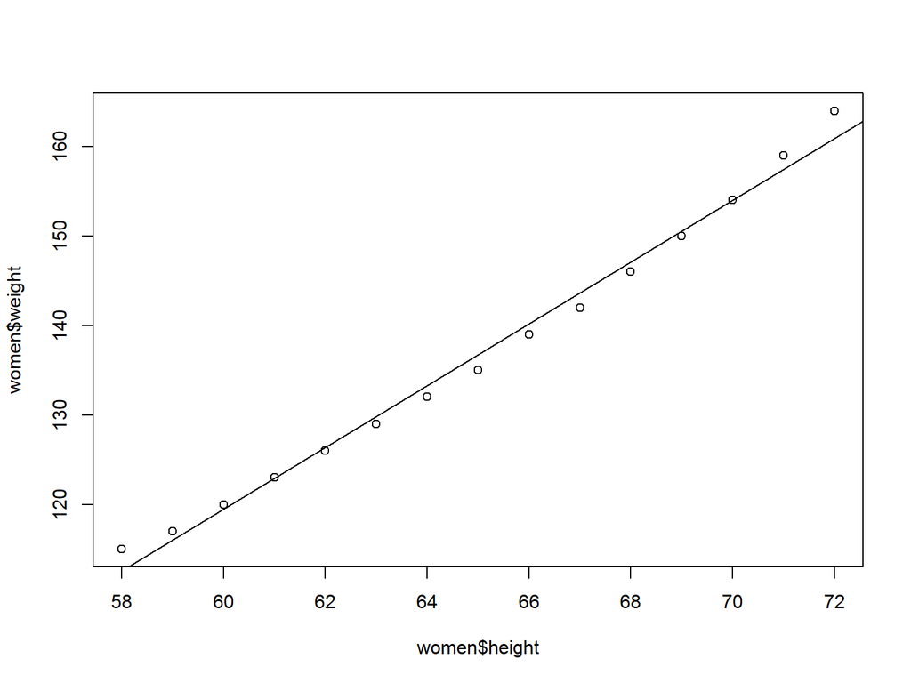

```r
plot(women$height, women$weight)  #绘制散点图
abline(myfit)   #绘制回归直线
```

## 一元高次线性回归

一元高次线性回归也称为多项式回归，在回归方程中含有自变量的高次项。例如，对数据框women，我们使用二次方法来拟合：

$$\mbox{weight}=\alpha_0 + \alpha_1 * \mbox{height} + \alpha_2 * \mbox{height}^2$$

```r
myfit <- lm(weight~height+I(height^2), data=women)
summary(myfit)
```

```
##
## Call:
## lm(formula = weight ~ height + I(height^2), data = women)
##
## Residuals:
##      Min       1Q   Median       3Q      Max
## -0.50941 -0.29611 -0.00941  0.28615  0.59706
##
## Coefficients:
##              Estimate Std. Error t value Pr(>|t|)
## (Intercept) 261.87818   25.19677  10.393 2.36e-07 ***
## height       -7.34832    0.77769  -9.449 6.58e-07 ***
## I(height^2)   0.08306    0.00598  13.891 9.32e-09 ***
## ---
## Signif. codes:  0 '***' 0.001 '**' 0.01 '*' 0.05 '.' 0.1 ' ' 1
##
## Residual standard error: 0.3841 on 12 degrees of freedom
## Multiple R-squared:  0.9995, Adjusted R-squared:  0.9994
## F-statistic: 1.139e+04 on 2 and 12 DF,  p-value: < 2.2e-16
```

这说明，我们得到的回归方程是：
$$\mbox{weight}=261.87818 -7.34832 * \mbox{height} + 0.08306 * \mbox{height}^2$$
三个系数都是显著不为0。

DIY: 安装`car`包，使用`scatterplot()`绘制散点图和拟合曲线。

## 多元线性回归

多元线性回归与一元线性回归基本相同，只是公式稍复杂一点。

我们以R自带的数据state.x77为例来说明。state.x77记录了1977年美国各州的统计信息，包括人口(Population)、文盲率(Illiteracy)、收入水平(Income)、凶杀率(Murder)、结霜天数(Frost)等。注意，state.x77是一个matrix，我们先把它转换为一个data.frame，然后做一个多元线性回归。

```r
mydata <- as.data.frame(state.x77[, c("Murder", "Population", "Illiteracy", "Income", "Frost")])
myfit <- lm(Murder ~ Population + Illiteracy + Income + Frost, data=mydata)
summary(myfit)
```

```
##
## Call:
## lm(formula = Murder ~ Population + Illiteracy + Income + Frost,
##     data = mydata)
##
## Residuals:
##     Min      1Q  Median      3Q     Max
## -4.7960 -1.6495 -0.0811  1.4815  7.6210
##
## Coefficients:
##              Estimate Std. Error t value Pr(>|t|)
## (Intercept) 1.235e+00  3.866e+00   0.319   0.7510
## Population  2.237e-04  9.052e-05   2.471   0.0173 *
## Illiteracy  4.143e+00  8.744e-01   4.738 2.19e-05 ***
## Income      6.442e-05  6.837e-04   0.094   0.9253
## Frost       5.813e-04  1.005e-02   0.058   0.9541
## ---
## Signif. codes:  0 '***' 0.001 '**' 0.01 '*' 0.05 '.' 0.1 ' ' 1
##
## Residual standard error: 2.535 on 45 degrees of freedom
## Multiple R-squared:  0.567,  Adjusted R-squared:  0.5285
## F-statistic: 14.73 on 4 and 45 DF,  p-value: 9.133e-08
```

**交互项**

多元线性回归方程中可以有两个（或多个）变量构成的交互项。如果交互项的系数显著不为0，那么意味着存在着调节效应。

我们以mtcars数据框为例，研究车辆的重量(weight)对续航能力(mpg)的影响，预期这两个变量是负相关的，但是我们还要考虑发动机的动力(hp)对这种相关关系会有调节，于是构造一个带交互项的回归模型：

```r
myfit <- lm(mpg ~ hp + wt + hp:wt, data=mtcars)
summary(myfit)
```

```
##
## Call:
## lm(formula = mpg ~ hp + wt + hp:wt, data = mtcars)
##
## Residuals:
##     Min      1Q  Median      3Q     Max
## -3.0632 -1.6491 -0.7362  1.4211  4.5513
##
## Coefficients:
##             Estimate Std. Error t value Pr(>|t|)
## (Intercept) 49.80842    3.60516  13.816 5.01e-14 ***
## hp          -0.12010    0.02470  -4.863 4.04e-05 ***
## wt          -8.21662    1.26971  -6.471 5.20e-07 ***
## hp:wt        0.02785    0.00742   3.753 0.000811 ***
## ---
## Signif. codes:  0 '***' 0.001 '**' 0.01 '*' 0.05 '.' 0.1 ' ' 1
##
## Residual standard error: 2.153 on 28 degrees of freedom
## Multiple R-squared:  0.8848, Adjusted R-squared:  0.8724
## F-statistic: 71.66 on 3 and 28 DF,  p-value: 2.981e-13
```

我们得到的回归方程是：

$$\mbox{mpg}=49.8-0.12*\mbox{hp}-8.21662*\mbox{wt}+0.02785*\mbox{hp}*\mbox{wt}$$

所有系数全都显著不为0。回归结果说明车重(weight)的确与续航能力(mpg)负相关，动力(hp)对此关系具有调节能力。

DIY

- `cor()`可计算各变量之间的相关系数；
- `car::scatterplot()`可图示两两变量之间的关系；
- `effect::effect()`可图示交互项的作用；

## 分析回归结果

在得到回归模型之后，我们可以用以下函数对回归模型进行分析。

| 函数 | 功能 |
| --- | --- |
| summary() | 展示拟合模型的详细结果 |
| coefficients() | 列出拟合模型的模型参数（截距和各自变量的系数） |
| confint() | 提供模型参数的置信区间（默认95%） |
| fitted() | 列出拟合模型的预测值 |
| residuals() | 列出拟合模型的残差 |
| anova() | 生成一个拟合模型的方差分析表，或者比较两个或更多拟合模型的方差分析表 |
| vcov() | 列出模型参数的协方差矩阵 |
| AIC() | 计算赤池信息统计量 |
| plot() | 生成评价拟合模型的诊断图 |
| predict() | 用拟合模型对新的数据集预测响应变量的值 |

```r
mymodel <- lm(weight~height, data=women)
summary(mymodel)
```

```
##
## Call:
## lm(formula = weight ~ height, data = women)
##
## Residuals:
##     Min      1Q  Median      3Q     Max
## -1.7333 -1.1333 -0.3833  0.7417  3.1167
##
## Coefficients:
##              Estimate Std. Error t value Pr(>|t|)
## (Intercept) -87.51667    5.93694  -14.74 1.71e-09 ***
## height        3.45000    0.09114   37.85 1.09e-14 ***
## ---
## Signif. codes:  0 '***' 0.001 '**' 0.01 '*' 0.05 '.' 0.1 ' ' 1
##
## Residual standard error: 1.525 on 13 degrees of freedom
## Multiple R-squared:  0.991,  Adjusted R-squared:  0.9903
## F-statistic:  1433 on 1 and 13 DF,  p-value: 1.091e-14
```

```r
coefficients(mymodel)  #查看截距和各自变量的系数，返回值是一个向量
```

```
## (Intercept)      height
##   -87.51667     3.45000
```

```r
confint(mymodel, level=0.99)  #查看截距和各自变量系数的置信区间, level的默认值是0.95
```

```
##                   0.5 %     99.5 %
## (Intercept) -105.400380 -69.632954
## height         3.175472   3.724528
```

```r
fitted(mymodel) #因变量的拟合值，即在回归直线上的y值
```

```
##        1        2        3        4        5        6        7        8
## 112.5833 116.0333 119.4833 122.9333 126.3833 129.8333 133.2833 136.7333
##        9       10       11       12       13       14       15
## 140.1833 143.6333 147.0833 150.5333 153.9833 157.4333 160.8833
```

```r
residuals(mymodel)  #各点的残差值，等于women$weight - fitted(mymodel)
```

```
##           1           2           3           4           5           6
##  2.41666667  0.96666667  0.51666667  0.06666667 -0.38333333 -0.83333333
##           7           8           9          10          11          12
## -1.28333333 -1.73333333 -1.18333333 -1.63333333 -1.08333333 -0.53333333
##          13          14          15
##  0.01666667  1.56666667  3.11666667
```

```r
newdata <- data.frame(height=c(90, 95, 100, 105))
predict(mymodel, newdata) #预测当height=90, 95, 100, 105时，weight=?
```

```
##        1        2        3        4
## 222.9833 240.2333 257.4833 274.7333
```

```r
#计算y的置信区间，即对y的实际值做区间估计
predict(mymodel, newdata, interval="prediction", level=0.99)
```

```
##        fit      lwr      upr
## 1 222.9833 214.6399 231.3268
## 2 240.2333 230.7287 249.7380
## 3 257.4833 246.7673 268.1993
## 4 274.7333 262.7711 286.6955
```

```r
#计算回归直线上y点的置信区间，即对y的期望值做区间估计
#y的期望值+随机扰动=y的实际值
predict(mymodel, newdata, interval="confidence", level=0.99)
```

```
##        fit      lwr      upr
## 1 222.9833 216.0184 229.9483
## 2 240.2333 231.9125 248.5542
## 3 257.4833 247.8019 267.1648
## 4 274.7333 263.6883 285.7783
```

```r
myfit <- lm(mpg ~ hp + wt + hp:wt, data=mtcars)
newdata <- data.frame(hp=c(100, 110, 105), wt=c(2.6, 2.8, 2.76))
predict(myfit, newdata)  #多元线性回归模型的预测值
```

```
##        1        2        3
## 23.67551 22.16788 22.59021
```

```r
newdata$mpg <- predict(myfit, newdata)  #将因变量与自变量的值合并在一起
newdata
```

```
##    hp   wt      mpg
## 1 100 2.60 23.67551
## 2 110 2.80 22.16788
## 3 105 2.76 22.59021
```

## 自学内容

- 回归诊断
- 异常观测值
- 选择最佳回归模型